# HeartDiseaseUpdated

### 💡 Evaluation metrics for Classification models:

- Accuracy: Accuracy is the most straightforward metric and measures the overall correctness of the model's predictions. It calculates the ratio of correct predictions to the total number of predictions made.
- Precision: Precision measures the proportion of correctly predicted positive instances (true positives) out of the total instances predicted as positive (true positives + false positives). It indicates the model's ability to avoid false positives.
- Recall (Sensitivity or True Positive Rate): Recall calculates the proportion of correctly predicted positive instances (true positives) out of the total actual positive instances (true positives + false negatives). It indicates the model's ability to identify positive instances.
- Specificity (True Negative Rate): Specificity measures the proportion of correctly predicted negative instances (true negatives) out of the total actual negative instances (true negatives + false positives). It indicates the model's ability to identify negative instances.
- F1 Score: The F1 score is the harmonic mean of precision and recall. It provides a balanced measure between precision and recall, considering both false positives and false negatives. It is useful when the class distribution is imbalanced.
- Area Under the ROC Curve (AUC-ROC): The ROC curve represents the trade-off between true positive rate (sensitivity) and false positive rate (1 - specificity) at various classification thresholds. AUC-ROC measures the overall performance of the model across different thresholds, providing a single value to compare different models. A higher AUC-ROC indicates better model performance.
- Cohen's Kappa: Cohen's Kappa is a statistic that measures the agreement between the predicted and actual classifications, while taking into account the agreement that could occur by chance. It is useful when evaluating models with imbalanced class distributions.

### 💡 Popular Classification Models:

- **Logistic Regression:** Logistic regression models the probability of a binary or multi-class outcome using a logistic function. It is widely used for binary classification tasks and can be extended to handle multiple classes.

  ```
  from sklearn.linear_model import LogisticRegression
  ```

- **Decision Tree:** Decision tree classifiers partition the feature space into regions based on feature values. Each partition represents a leaf node with a predicted class label.

  ```
  from sklearn.tree import DecisionTreeClassifier
  ```

- **Random Forest:** Random forest classifiers are ensemble models that combine multiple decision trees. They improve prediction accuracy by averaging the predictions of individual trees.

  ```
  from sklearn.ensemble import RandomForestClassifier
  ```

- **Gradient Boosting:** Gradient boosting classifiers build an ensemble of weak learners, typically decision trees, in a sequential manner. Each subsequent model corrects the errors made by the previous models, leading to improved predictions.

  ```
  from sklearn.ensemble import GradientBoostingClassifier
  ```

- **Support Vector Machines (SVM):** SVM classifiers find the optimal hyperplane that separates the data into different classes with the maximum margin. They can handle linear and nonlinear classification tasks.

  ```
  from sklearn.svm import SVC
  ```

- **K-Nearest Neighbors (KNN):** KNN classifiers predict the class label of an instance by considering the labels of its k nearest neighbors in the feature space.

  ```
  from sklearn.neighbors import KNeighborsClassifier
  ```

- **Naive Bayes:** Naive Bayes classifiers are probabilistic models that use Bayes' theorem with strong independence assumptions between features. They are fast and effective for text classification and other tasks.

  ```
  from sklearn.naive_bayes import GaussianNB
  ```

- **Neural Networks:** Neural network classifiers utilize deep learning architectures to model complex relationships between predictors and class labels. They consist of multiple interconnected layers of artificial neurons that learn to approximate the target function.

  ```
  from sklearn.neural_network import MLPClassifier
  ```

- **AdaBoost:** AdaBoost is an ensemble method that combines multiple weak classifiers to create a strong classifier. It assigns higher weights to misclassified instances, focusing on difficult examples.

  ```
  from sklearn.ensemble import AdaBoostClassifier
  ```

- **Gradient Boosting with XGBoost:** XGBoost is an optimized gradient boosting classifier known for its high performance and scalability. It offers various boosting algorithms and regularization techniques.

  ```
  import xgboost as xgb
  ```

- **Gradient Boosting with LightGBM:** LightGBM is another gradient boosting classifier that provides high efficiency and handles large-scale data. It offers faster training speed and supports categorical features.

  ```
  import lightgbm as lgb
  ```

- **Gradient Boosting with CatBoost:** CatBoost is a gradient boosting classifier that supports categorical features and incorporates innovative techniques such as ordered boosting and symmetric trees.

  ```
  import catboost as cb
  ```

- **Logistic Regression with L1 Regularization (Lasso):** L1 regularized logistic regression can perform feature selection by setting some coefficients to exactly zero. It helps to reduce the number of irrelevant features.

  ```
  from sklearn.linear_model import LogisticRegression
  ```

- **Support Vector Machines with RBF Kernel:** SVM classifiers with radial basis function (RBF) kernel can handle nonlinear classification tasks by mapping the input space into a higher-dimensional feature space.

  ```
  from sklearn.svm import SVC
  ```

- **Extra Trees:** Extra Trees classifiers are ensemble models similar to random forests but with some differences in the way they build individual trees and handle feature splits.

  ```
  from sklearn.ensemble import ExtraTreesClassifier
  ```

- **Gaussian Process:** Gaussian process classifiers model the decision boundary as a distribution over functions. They provide a nonparametric approach to classification that captures uncertainty in predictions.

  ```
  from sklearn.gaussian_process import GaussianProcessClassifier
  ```

- **Nearest Centroid:** Nearest Centroid classifiers compute the centroids of each class and classify instances based on the nearest centroid. They are simple and fast but assume that all features are equally important.

  ```
  from sklearn.neighbors import NearestCentroid
  ```

- **Quadratic Discriminant Analysis (QDA):** QDA classifiers model the probability distribution of each class using a quadratic function. They assume a quadratic decision boundary and can capture complex relationships.

  ```
  from sklearn.discriminant_analysis import QuadraticDiscriminantAnalysis
  ```

- **Linear Discriminant Analysis (LDA):** LDA classifiers find a linear combination of features that maximizes the separation between classes. They project the data onto a lower-dimensional space while preserving class information.

  ```
  from sklearn.discriminant_analysis import LinearDiscriminantAnalysis
  ```

- **HistGradientBoosting Classifier:** HistGradientBoosting is a histogram-based gradient boosting classifier that provides fast and accurate predictions. It can handle large-scale datasets.

  ```
  from sklearn.ensemble import HistGradientBoostingClassifier
  ```

- **Bagging:** Bagging classifiers combine multiple base estimators, such as decision trees or SVMs, by training them on random subsets of the training data. They reduce variance and improve generalization.

  ```
  from sklearn.ensemble import BaggingClassifier
  ```

- **Calibrated Classifier:** Calibrated classifiers assign class probabilities calibrated to the predicted scores. They can improve the reliability of probabilistic predictions.

  ```
  from sklearn.calibration import CalibratedClassifierCV
  ```

- **Multi-layer Perceptron (MLP) Classifier:** MLP classifiers are feedforward neural networks with multiple hidden layers. They can learn complex patterns and are effective for a wide range of classification tasks.

  ```
  from sklearn.neural_network import MLPClassifier
  ```

### 🛫 Imports

```python
'''
--------------------------------------------------------
CLASSIFICATION MODELS
--------------------------------------------------------
'''
from sklearn.ensemble import RandomForestClassifier
from sklearn.ensemble import BaggingClassifier
from sklearn.linear_model import LogisticRegression
from sklearn import svm
from sklearn.naive_bayes import GaussianNB
from sklearn.tree import DecisionTreeClassifier
from sklearn.ensemble import GradientBoostingClassifier
from sklearn.ensemble import AdaBoostClassifier
from xgboost import XGBClassifier
from lightgbm import LGBMClassifier
from catboost import CatBoostClassifier
from sklearn.neighbors import KNeighborsClassifier
from sklearn.ensemble import VotingClassifier
from sklearn.svm import SVC

'''
--------------------------------------------------------
FEAUTURE ENGINEERING
--------------------------------------------------------
'''

from sklearn.base import BaseEstimator, TransformerMixin
from sklearn.metrics import plot_confusion_matrix, classification_report
from sklearn.pipeline import make_pipeline
from sklearn.preprocessing import MinMaxScaler
from sklearn.model_selection import GridSearchCV

'''
--------------------------------------------------------
OTHER
--------------------------------------------------------
'''
import missingno as msno
import tensorflow as tf
from tensorflow import keras
import numpy as np
import matplotlib.pyplot as plt
from sklearn.model_selection import train_test_split, cross_val_score
from sklearn.metrics import mean_squared_error, r2_score, accuracy_score, roc_auc_score
from sklearn.metrics import accuracy_score, r2_score, roc_auc_score, precision_score, recall_score, f1_score
import seaborn as sns
import plotly.express as px
import pandas as pd
import catboost as cb
from IPython.display import Image
import warnings
import optuna

def ignoreWarnings():
    warnings.filterwarnings('ignore')
```

### 💡 The first step is to import the data

```python
data = pd.read_csv('Csv Files/heart.csv')
pd.set_option('display.max_columns', None) #This will display all the columns in the dataframe
data
```

|  | Age | Sex | ChestPainType | RestingBP | Cholesterol | FastingBS | RestingECG | MaxHR | ExerciseAngina | Oldpeak | ST_Slope | HeartDisease |
| --- | --- | --- | --- | --- | --- | --- | --- | --- | --- | --- | --- | --- |
| 0 | 40 | M | ATA | 140 | 289 | 0 | Normal | 172 | N | 0.0 | Up | 0 |
| 1 | 49 | F | NAP | 160 | 180 | 0 | Normal | 156 | N | 1.0 | Flat | 1 |
| 2 | 37 | M | ATA | 130 | 283 | 0 | ST | 98 | N | 0.0 | Up | 0 |
| 3 | 48 | F | ASY | 138 | 214 | 0 | Normal | 108 | Y | 1.5 | Flat | 1 |
| 4 | 54 | M | NAP | 150 | 195 | 0 | Normal | 122 | N | 0.0 | Up | 0 |
| ... | ... | ... | ... | ... | ... | ... | ... | ... | ... | ... | ... | ... |
| 913 | 45 | M | TA | 110 | 264 | 0 | Normal | 132 | N | 1.2 | Flat | 1 |
| 914 | 68 | M | ASY | 144 | 193 | 1 | Normal | 141 | N | 3.4 | Flat | 1 |
| 915 | 57 | M | ASY | 130 | 131 | 0 | Normal | 115 | Y | 1.2 | Flat | 1 |
| 916 | 57 | F | ATA | 130 | 236 | 0 | LVH | 174 | N | 0.0 | Flat | 1 |
| 917 | 38 | M | NAP | 138 | 175 | 0 | Normal | 173 | N | 0.0 | Up | 0 |

918 rows × 12 columns

### 📊 EDA

| Variable Name | Units or Categories | Description | Qaul / Quan | Type |
| --- | --- | --- | --- | --- |
| Age | Years | How many years the person has been alive | Quantitative | Discrete |
| Sex | Male (M); Female(F) | What gender the person is | Qaulitative | Nominal |
| ChestPainType | Typical Angina (TA); Atypical Angina (ATA); Non-Anginal Pain (NAP); Asymptomatic (ASY) | What type of chest pain is the person experiencing | Qualitative | Nomial |
| RestingBP | mm Hg | The Patients resting Blood pressure | Quantitative | Discrete |
| Cholesterol | mm/dl | Patients Cholesterol levels | Quantitative | Discrete |
| FastingBS | 1: if FastingBS > 120 mg/dl, 0: otherwise | Fasting blood sugar | Qualitative | Nominal |
| RestingECG | Normal (Normal); Having ST-T wave abnormality (ST); Showing probable or definite left ventricular hypertrophy by Estes' criteria (LVH) | The patients Resting ECG | Qualitative | Nominal |
| MaxHR | Between 60 and 202 | The patients maximum heart rate achieved | Quantitative | Discrete |
| ExerciseAngina | Yes (Y); No (N) | If there was an exercise-induced angina | Qualitative | Nominal |
| Oldpeak | ST [Numeric value measured in depression] | ST depression induced by exercise relative to rest | Quantitative | Continuous |
| ST_Slope | Upsloping (Up); Flat (Flat); Downsloping (Down) | The slope of the peak exercise ST segment | Qualitative | Nominal |
| HeartDisease | Heart Disease (1); Normal (0) | Output class that describes if someone has heart disease or not | Qualitative | Nominal |

```python
def summary(df):
        # Print the shape of the DataFrame
        print(f'data shape: {df.shape}')
        # Create a summary DataFrame
        summ = pd.DataFrame(df.dtypes, columns=['data type'])
        # Calculate the number of missing values
        summ['#missing'] = df.isnull().sum().values
        # Calculate the percentage of missing values
        summ['%missing'] = df.isnull().sum().values / len(df) * 100
        # Calculate the number of unique values
        summ['#unique'] = df.nunique().values
        # Create a descriptive DataFrame
        desc = pd.DataFrame(df.describe(include='all').transpose())
        # Add the minimum, maximum, and first three values to the summary DataFrame
        summ['min'] = desc['min'].values
        summ['max'] = desc['max'].values
        summ['first value'] = df.loc[0].values
        summ['second value'] = df.loc[1].values
        summ['third value'] = df.loc[2].values

        # Return the summary DataFrame
        return summ

summary(data)
```

```
data shape: (918, 12)
```

|  | data type | #missing | %missing | #unique | min | max | first value | second value | third value |
| --- | --- | --- | --- | --- | --- | --- | --- | --- | --- |
| Age | int64 | 0 | 0.0 | 50 | 28.0 | 77.0 | 40 | 49 | 37 |
| Sex | object | 0 | 0.0 | 2 | NaN | NaN | M | F | M |
| ChestPainType | object | 0 | 0.0 | 4 | NaN | NaN | ATA | NAP | ATA |
| RestingBP | int64 | 0 | 0.0 | 67 | 0.0 | 200.0 | 140 | 160 | 130 |
| Cholesterol | int64 | 0 | 0.0 | 222 | 0.0 | 603.0 | 289 | 180 | 283 |
| FastingBS | int64 | 0 | 0.0 | 2 | 0.0 | 1.0 | 0 | 0 | 0 |
| RestingECG | object | 0 | 0.0 | 3 | NaN | NaN | Normal | Normal | ST |
| MaxHR | int64 | 0 | 0.0 | 119 | 60.0 | 202.0 | 172 | 156 | 98 |
| ExerciseAngina | object | 0 | 0.0 | 2 | NaN | NaN | N | N | N |
| Oldpeak | float64 | 0 | 0.0 | 53 | -2.6 | 6.2 | 0.0 | 1.0 | 0.0 |
| ST_Slope | object | 0 | 0.0 | 3 | NaN | NaN | Up | Flat | Up |
| HeartDisease | int64 | 0 | 0.0 | 2 | 0.0 | 1.0 | 0 | 1 | 0 |

```python
for col in data.select_dtypes(include=[np.number]).columns:
  print(f"{col} has {data[col].nunique()} unique value")
```

```
Age has 50 unique value
RestingBP has 67 unique value
Cholesterol has 222 unique value
FastingBS has 2 unique value
MaxHR has 119 unique value
Oldpeak has 53 unique value
HeartDisease has 2 unique value
```

```python
string_col = data.select_dtypes(include="object").columns
data[string_col] = data[string_col].astype("string")
data.info()
```

```
<class 'pandas.core.frame.DataFrame'>
RangeIndex: 918 entries, 0 to 917
Data columns (total 12 columns):
 #   Column          Non-Null Count  Dtype
---  ------          --------------  -----
 0   Age             918 non-null    int64
 1   Sex             918 non-null    string
 2   ChestPainType   918 non-null    string
 3   RestingBP       918 non-null    int64
 4   Cholesterol     918 non-null    int64
 5   FastingBS       918 non-null    int64
 6   RestingECG      918 non-null    string
 7   MaxHR           918 non-null    int64
 8   ExerciseAngina  918 non-null    string
 9   Oldpeak         918 non-null    float64
 10  ST_Slope        918 non-null    string
 11  HeartDisease    918 non-null    int64
dtypes: float64(1), int64(6), string(5)
memory usage: 86.2 KB
```

### 💡 Let's reduce the size of the variables to help us save memory

```python
int_col = data.select_dtypes(include="int64").columns
float_col = data.select_dtypes(include="float64").columns
#Convert to int8, int16, int32, float8, float16, float32 to save memory
for col in int_col:
    if data[col].max()<128:
        data[col] = data[col].astype('int8')
    elif data[col].max()<32768:
        data[col] = data[col].astype('int16')
    else:
        data[col].astype('int32')

for col in float_col:
    if data[col].max()<32768:
        data[col] = data[col].astype('float16')
    else:
        data[col].astype('float32')

data.info()
```

```
<class 'pandas.core.frame.DataFrame'>
RangeIndex: 918 entries, 0 to 917
Data columns (total 12 columns):
 #   Column          Non-Null Count  Dtype
---  ------          --------------  -----
 0   Age             918 non-null    int8
 1   Sex             918 non-null    string
 2   ChestPainType   918 non-null    string
 3   RestingBP       918 non-null    int16
 4   Cholesterol     918 non-null    int16
 5   FastingBS       918 non-null    int8
 6   RestingECG      918 non-null    string
 7   MaxHR           918 non-null    int16
 8   ExerciseAngina  918 non-null    string
 9   Oldpeak         918 non-null    float16
 10  ST_Slope        918 non-null    string
 11  HeartDisease    918 non-null    int8
dtypes: float16(1), int16(3), int8(3), string(5)
memory usage: 45.8 KB
```

### 💡 Let's grab the column names for categorical columns and numerical columns

```python
cat_cols = data.select_dtypes("string").columns.to_list()
cat_cols.append('FastingBS')
print(f'''The categorical columns are
      {cat_cols}
      ''')



num_cols = [i for i in data.columns if i not in cat_cols and i != 'HeartDisease']
print(f'''The categorical columns are
      {num_cols}
      ''')
```

```
The categorical columns are
      ['Sex', 'ChestPainType', 'RestingECG', 'ExerciseAngina', 'ST_Slope', 'FastingBS']

The categorical columns are
      ['Age', 'RestingBP', 'Cholesterol', 'MaxHR', 'Oldpeak']
```

```python
data.describe()
```

|  | Age | RestingBP | Cholesterol | FastingBS | MaxHR | Oldpeak | HeartDisease |
| --- | --- | --- | --- | --- | --- | --- | --- |
| count | 918.000000 | 918.000000 | 918.000000 | 918.000000 | 918.000000 | 918.000000 | 918.000000 |
| mean | 53.510893 | 132.396514 | 198.799564 | 0.233115 | 136.809368 | 0.887207 | 0.553377 |
| std | 9.432617 | 18.514154 | 109.384145 | 0.423046 | 25.460334 | 1.066406 | 0.497414 |
| min | 28.000000 | 0.000000 | 0.000000 | 0.000000 | 60.000000 | -2.599609 | 0.000000 |
| 25% | 47.000000 | 120.000000 | 173.250000 | 0.000000 | 120.000000 | 0.000000 | 0.000000 |
| 50% | 54.000000 | 130.000000 | 223.000000 | 0.000000 | 138.000000 | 0.600098 | 1.000000 |
| 75% | 60.000000 | 140.000000 | 267.000000 | 0.000000 | 156.000000 | 1.500000 | 1.000000 |
| max | 77.000000 | 200.000000 | 603.000000 | 1.000000 | 202.000000 | 6.199219 | 1.000000 |

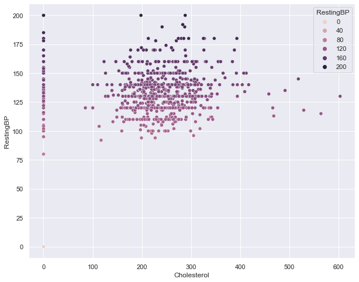

```python
plt.figure(figsize=(10, 8))
sns.scatterplot(data=data,x='Cholesterol',y='RestingBP',hue='RestingBP')
```

### 💡 This could be a bit of a problem.

Let's convert the 0s to nulls and then visualise them </font>

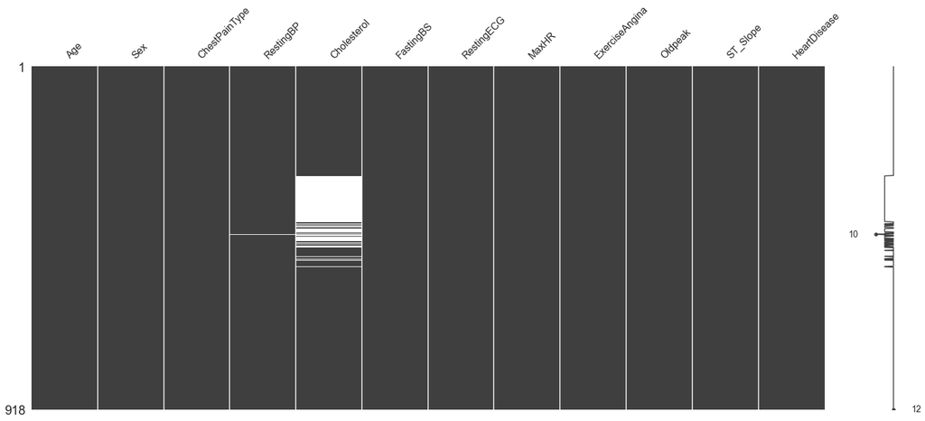

```python
data['Cholesterol'].replace(0,np.nan,inplace=True)
data['RestingBP'].replace(0,np.nan,inplace=True)

msno.matrix(data)
```

### 💡 Findings

It looks like there are null values in the centre of the data.  
Assuming these values where collected in chronological order, there was a time where someone was inputting values incorrectly.  
Or one of the sources was unreliable.

When we build the model we can experiment with different techniques to fill these gaps.  
For now we will drop the values which are = 0.  
For the sake of analysing the data. </font>

```python
data = data.dropna()
data.describe()
```

|  | Age | RestingBP | Cholesterol | FastingBS | MaxHR | Oldpeak | HeartDisease |
| --- | --- | --- | --- | --- | --- | --- | --- |
| count | 746.000000 | 746.000000 | 746.000000 | 746.000000 | 746.000000 | 746.000000 | 746.000000 |
| mean | 52.882038 | 133.022788 | 244.635389 | 0.167560 | 140.226542 | 0.901367 | 0.477212 |
| std | 9.505888 | 17.282750 | 59.153524 | 0.373726 | 24.524107 | 1.072266 | 0.499816 |
| min | 28.000000 | 92.000000 | 85.000000 | 0.000000 | 69.000000 | -0.099976 | 0.000000 |
| 25% | 46.000000 | 120.000000 | 207.250000 | 0.000000 | 122.000000 | 0.000000 | 0.000000 |
| 50% | 54.000000 | 130.000000 | 237.000000 | 0.000000 | 140.000000 | 0.500000 | 0.000000 |
| 75% | 59.000000 | 140.000000 | 275.000000 | 0.000000 | 160.000000 | 1.500000 | 1.000000 |
| max | 77.000000 | 200.000000 | 603.000000 | 1.000000 | 202.000000 | 6.199219 | 1.000000 |

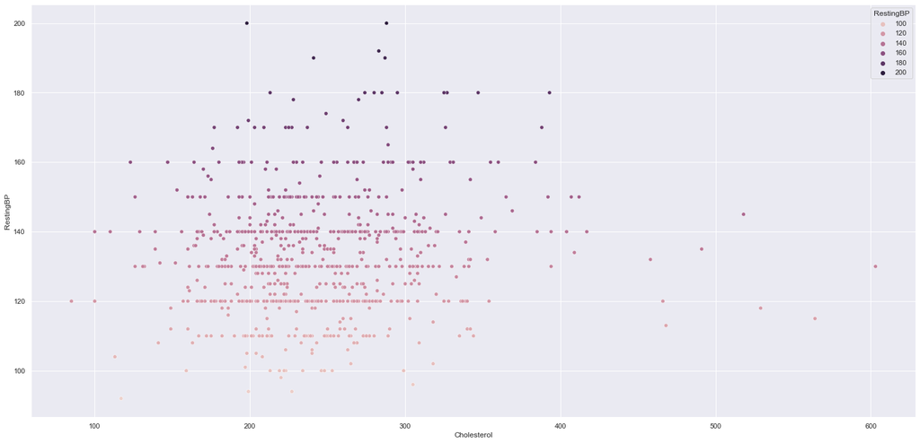

```python
sns.scatterplot(data=data,x='Cholesterol',y='RestingBP',hue='RestingBP')
```

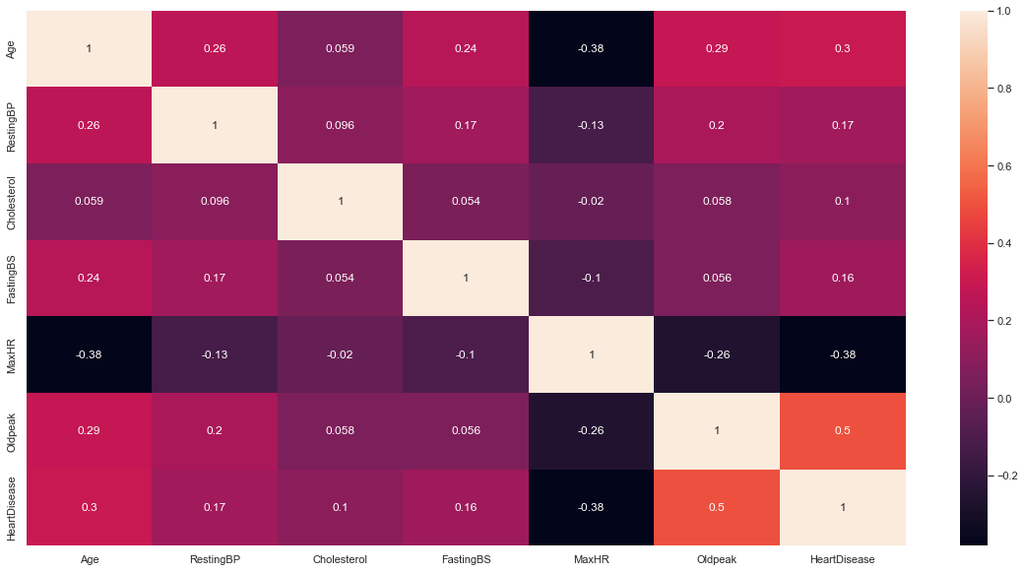

```python
sns.set(rc = {'figure.figsize':(20,10)})
sns.heatmap(data.corr(), annot=True) #By saying annot=True it writes the correlation in each cell
```

### 💡 Findings

We see that age and heart disease doesn't seem to have a strong relationship.  
But there is a slightly notible negative correlation between MaxHeartRate and HeartDisease.  
This means that as the MaxHeartRate increases the chance of heart disease decreases.  
The exact opposite could also be noticed with the Oldpeak.

A problem we have here is that every feature here is numeric, so we are completely disregarding the categorical features. (Apart from heart disease)  
So to quickly fix that we will turn the categorical features into dummy variables. </font>

```python
cat_cols.remove('Sex')
cat_cols.remove('FastingBS')
dataFrameOne = pd.get_dummies(data, columns = cat_cols, drop_first = False)
dataFrameOne = pd.get_dummies(dataFrameOne, columns = ['Sex'], drop_first = True)
cat_cols.append('Sex')
cat_cols.append('FastingBS')
dataFrameOne
```

|  | Age | RestingBP | Cholesterol | FastingBS | MaxHR | Oldpeak | HeartDisease | ChestPainType_ASY | ChestPainType_ATA | ChestPainType_NAP | ChestPainType_TA | RestingECG_LVH | RestingECG_Normal | RestingECG_ST | ExerciseAngina_N | ExerciseAngina_Y | ST_Slope_Down | ST_Slope_Flat | ST_Slope_Up | Sex_M |
| --- | --- | --- | --- | --- | --- | --- | --- | --- | --- | --- | --- | --- | --- | --- | --- | --- | --- | --- | --- | --- |
| 0 | 40 | 140.0 | 289.0 | 0 | 172 | 0.000000 | 0 | 0 | 1 | 0 | 0 | 0 | 1 | 0 | 1 | 0 | 0 | 0 | 1 | 1 |
| 1 | 49 | 160.0 | 180.0 | 0 | 156 | 1.000000 | 1 | 0 | 0 | 1 | 0 | 0 | 1 | 0 | 1 | 0 | 0 | 1 | 0 | 0 |
| 2 | 37 | 130.0 | 283.0 | 0 | 98 | 0.000000 | 0 | 0 | 1 | 0 | 0 | 0 | 0 | 1 | 1 | 0 | 0 | 0 | 1 | 1 |
| 3 | 48 | 138.0 | 214.0 | 0 | 108 | 1.500000 | 1 | 1 | 0 | 0 | 0 | 0 | 1 | 0 | 0 | 1 | 0 | 1 | 0 | 0 |
| 4 | 54 | 150.0 | 195.0 | 0 | 122 | 0.000000 | 0 | 0 | 0 | 1 | 0 | 0 | 1 | 0 | 1 | 0 | 0 | 0 | 1 | 1 |
| ... | ... | ... | ... | ... | ... | ... | ... | ... | ... | ... | ... | ... | ... | ... | ... | ... | ... | ... | ... | ... |
| 913 | 45 | 110.0 | 264.0 | 0 | 132 | 1.200195 | 1 | 0 | 0 | 0 | 1 | 0 | 1 | 0 | 1 | 0 | 0 | 1 | 0 | 1 |
| 914 | 68 | 144.0 | 193.0 | 1 | 141 | 3.400391 | 1 | 1 | 0 | 0 | 0 | 0 | 1 | 0 | 1 | 0 | 0 | 1 | 0 | 1 |
| 915 | 57 | 130.0 | 131.0 | 0 | 115 | 1.200195 | 1 | 1 | 0 | 0 | 0 | 0 | 1 | 0 | 0 | 1 | 0 | 1 | 0 | 1 |
| 916 | 57 | 130.0 | 236.0 | 0 | 174 | 0.000000 | 1 | 0 | 1 | 0 | 0 | 1 | 0 | 0 | 1 | 0 | 0 | 1 | 0 | 0 |
| 917 | 38 | 138.0 | 175.0 | 0 | 173 | 0.000000 | 0 | 0 | 0 | 1 | 0 | 0 | 1 | 0 | 1 | 0 | 0 | 0 | 1 | 1 |

746 rows × 20 columns

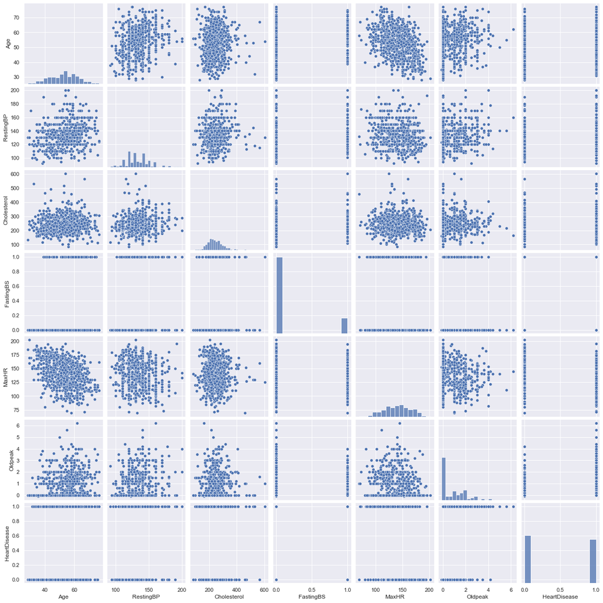

```python
sns.pairplot(data)
```

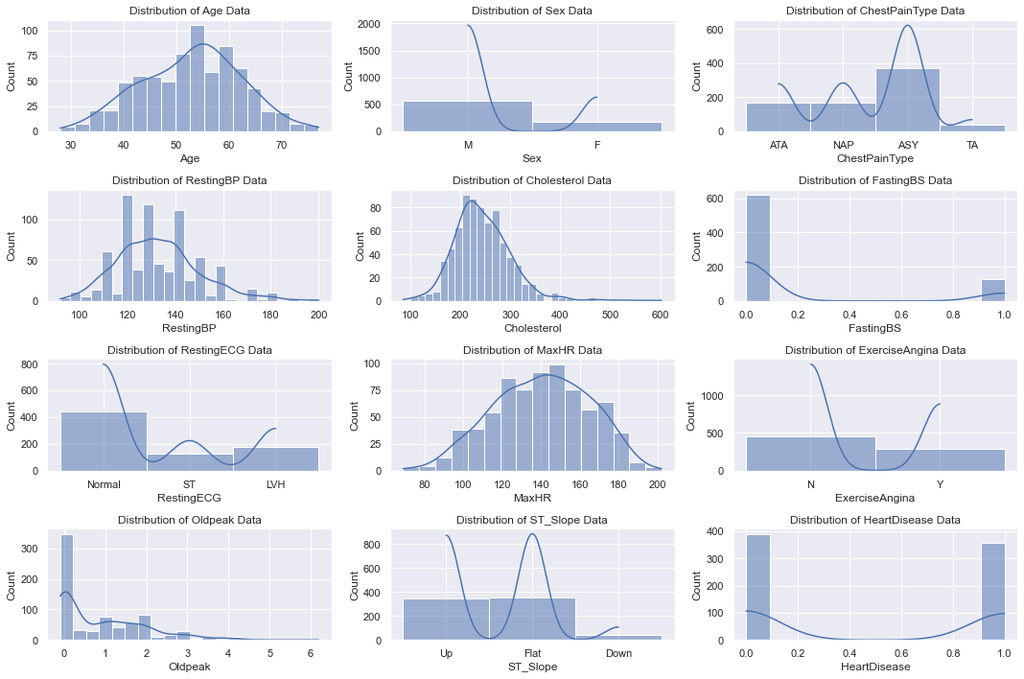

```python
plt.figure(figsize=(15,10))
for i,col in enumerate(data.columns,1):
    plt.subplot(4,3,i) #4 rows, 3 columns, and i is the number of the subplot
    plt.title(f"Distribution of {col} Data")
    sns.histplot(data[col],kde=True) #Setting Kernel Density Estimation (KDE) to True will draw a line, smoothing the distribution.
    plt.tight_layout()
    plt.plot()
```

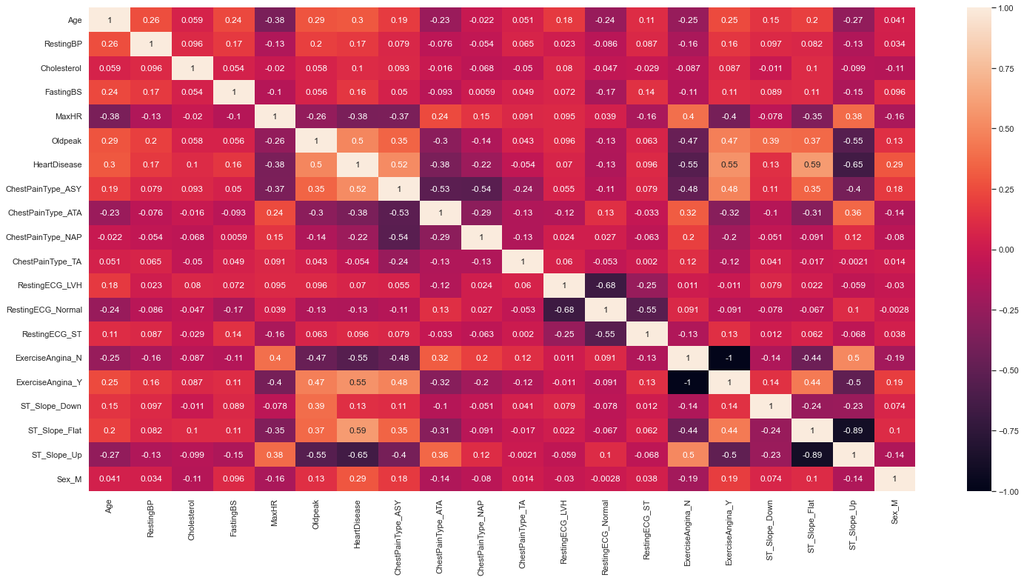

```python
sns.set(rc = {'figure.figsize':(25,12)})
sns.heatmap(dataFrameOne.corr(), annot=True) #We pass the correlation
```

### 💡 Findings

Looking at the correlations we see a somewhat notible negative correlation between MaxHR and HeartDisease.  
As well as notible positive correlation between Oldpeak and HeartDisease.  
A interestingly high positive correlation between Asymptomatic chest pains and HeartDisease.  
An interestinly high negative correlation between ATA chest pains and HeartDisease.

A very notable correlation between both Exercise Anginas and HeartDisease.  
We notice that N and Y have the same correlation but one is positive and one is negative.

```python
fig=px.histogram(data,
                 x="HeartDisease",
                 color="Sex",
                 hover_data=data.columns,
                 title="Heart Disease for Males and Females",
                 barmode="group")

fig.write_image("Graphs/histogram.png", format="png", width=800, height=600, scale=2)
fig.show()
```

### 💡 Findings

We notice something very quickly here.  
There seems to be a lot more males than females in this graph.  
That throws off the accuracy of what we are trying to see.  
It would be difficult to get a clear picture when there are just so many more males than females.  
Lets take a look at how many more males there are.  
To do this we make the x variable look at Sex instead of HeartDisease

```python
fig=px.histogram(data,
                 x="Sex",
                 hover_data=data.columns,
                 title="Count for Males and Females",
                 barmode="group")
fig.show()
```

```python
import plotly.express as px

fig = px.histogram(data,
                   x="Sex",
                   color="HeartDisease",
                   hover_data=data.columns,
                   title="Distribution of Heart Diseases for Male and Females",
                   barmode="group")

# Define the base font size that will be scaled according to the image size
base_font_size = 20

# Set the width and height directly within the figure using update_layout
fig.update_layout(width=980, height=560)

# Calculate the scale factor based on the desired image size
scale_factor = min(fig['layout']['width'] / 980, fig['layout']['height'] / 560)

# Calculate the adjusted font size
adjusted_title_font_size = int(base_font_size * scale_factor)
adjusted_axis_label_font_size = int(base_font_size * 0.8 * scale_factor)
adjusted_legend_font_size = int(base_font_size * 0.8 * scale_factor)

# Increase the text size for the title, axis labels, and legend
fig.update_layout(title_font=dict(size=adjusted_title_font_size),
                  xaxis_title_font=dict(size=adjusted_axis_label_font_size),
                  yaxis_title_font=dict(size=adjusted_axis_label_font_size),
                  legend_font=dict(size=adjusted_legend_font_size))

fig.write_image("Graphs/histogramMTry3.png", format="png", width=2560, height=1440, scale=1)
fig.show()
```

### 💡 Findings

Now this is very interesting, we see that the majority of Males tested had heart disease while the majority of females tested did not have heart disease.  
It looks like men where significantly more likely to have heart disease.

If we assume that the data is collected when someone goes to the doctor we can come to interesting conclusions from this.  
There are two things that may be true from this.

- Men may have a higher chance of getting Heart Disease.  
and  
- Men may be less inclined to go to the doctor until they are sure something is wrong, while women may be more willing to go to the doctor at the first sign of something wrong.  
-- This means that women may go in when they don't need to, while men only go in when they need to.  
--- Which results in more false alarms from women and less false alarms from men.  
---- There is something else in the dataset we can look at to get an idea of if this is the case.

To see if men only go when they are absolutely sure something is wrong we can look at the ChestPainType category.  
If there is not a large amount of asymptomatic records from the men and a lot of asymptomatic records from the women then it backs up the previous claim.

```python
fig=px.histogram(data,
                 x="Sex",
                 color="ChestPainType",
                 hover_data=data.columns,
                 title="Distribution of Chest pains for males and females",
                 barmode="group")

fig.write_image("Graphs/histogramChest.png", format="png", width=800, height=600, scale=3)
fig.show()
```

### 💡 Findings

I reject my hypothesis.

We see the complete opposite from what I previously guessed.  
We see that the large majority of male records where asymptomatic, while the majority of female records was also asymptomatic, but to a significantly smaller degree.

From this we can guess that the data is from a routine checkup and that men seem more inclined to go for said checkups.  
We come to this conclusion because why would a man who has no symptoms go to the doctors.  
But there is a problem with this conclusion again.  
If this was just a sample of random people coming for a checkup, does that mean that the vast majority of men suffer from heart disease?  
It doesn't make much sense, or it's an extremely scary find.  
There is more evidence to support that this may be the case.  
If we look at the distribution of ages, we see that the majority of ages are within the mid-life stages.  
Around the time that people generally start going for routine checkups.

We will use matplotlib to plot the data.  
Let's create a box and whisker diagram to see how the data is distributed.  
And a histogram to see the curve and distribution of the data.

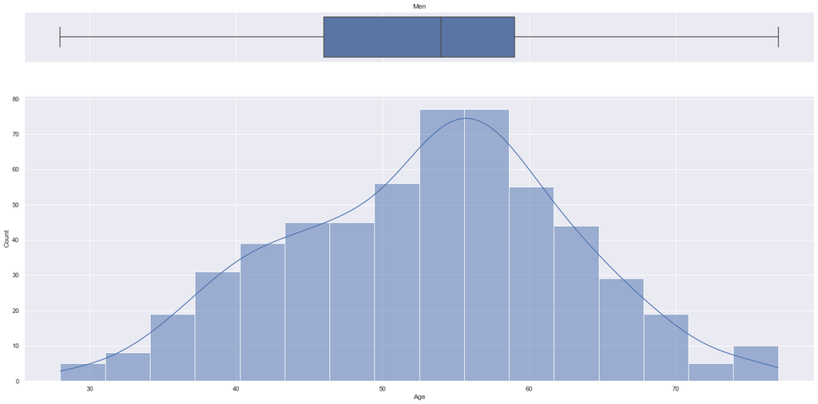

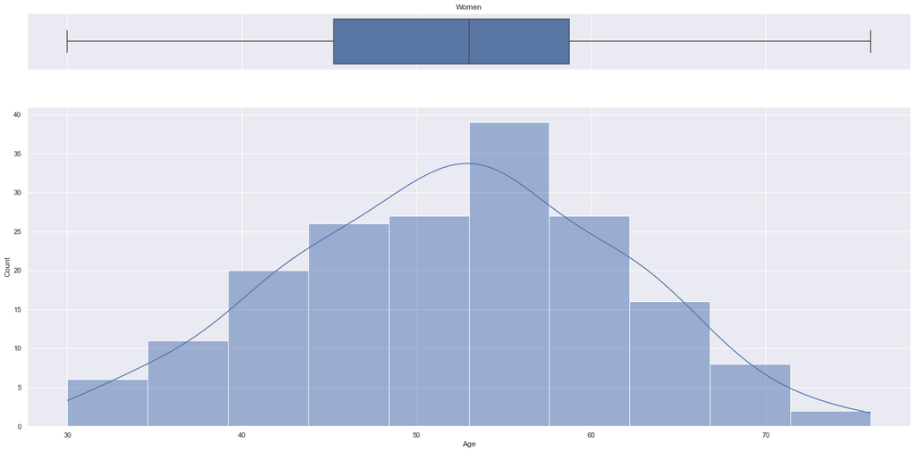

```
      Men records:
      count    564.000000
mean      53.102837
std        9.556603
min       28.000000
25%       46.000000
50%       54.000000
75%       59.000000
max       77.000000
Name: Age, dtype: float64


      Females records:
      count    182.000000
mean      52.197802
std        9.339774
min       30.000000
25%       45.250000
50%       53.000000
75%       58.750000
max       76.000000
Name: Age, dtype: float64
```

```python
import matplotlib.pyplot as plt

'''

---------------------------------------------------------------------------------------------------------------------------

We want to split the data into two groups.
Men and woman and study them seperately to see if there is a difference.

------

'''
menData = data[data['Sex'] == 'M']
femaleData = data[data['Sex'] == 'F']

def createPlot(data,gender):
    sns.set(style="darkgrid") #Set the style of the graph using seaborn
    f, (ax_box, ax_hist) = plt.subplots(2, sharex=True, gridspec_kw={"height_ratios": (.15, .85)}) #We want to plot two graphs on the same figure
    sns.boxplot(data=data,x='Age', ax=ax_box) #First one is a box and whisker diagram
    sns.histplot(data=data, x="Age", ax=ax_hist,kde=True) #Second one is a histogram
    ax_box.set(xlabel='')
    ax_box.set(title=gender)
    plt.show()

createPlot(menData,'Men')
createPlot(femaleData,'Women')

print(f'''
      Men records:
      {menData['Age'].describe()}
      ''')
print(f'''
      Females records:
      {femaleData['Age'].describe()}
      ''')
```

### 💡 Findings

Most of the records are from people in their 40s to 60s with not much variation between men and women.  
This supports the concept that these are from regular checkups as most people would be going around that age.

But there is one more variable we can look at.

Let's look at the ExerciseAngina variable.  
Which is simply if they had pain when they exercised.

```python
fig=px.histogram(data,
                 x="ExerciseAngina",
                 color="ChestPainType",
                 hover_data=data.columns,
                 title="Distribution of Chest pains ExerciseAngina",
                 barmode="group")
fig.write_image("Graphs/histogramExercise1.png", format="png", width=800, height=600, scale=3)
fig.show()

fig=px.histogram(data,
                 x="ExerciseAngina",
                 color="HeartDisease",
                 hover_data=data.columns,
                 title="Heart disease based on exercise anigna",
                 barmode="group")
fig.write_image("Graphs/histogramExercise.png", format="png", width=800, height=600, scale=3)
fig.show()
```

### 💡 Findings

It all makes sense now.  
At first you think, how could people who experienced chest pains from exercise be asymptomatic.  
It's because they ONLY experience chest pains from exercise.  
Passively they don't feel much pain, so they say they don't have chest pain for the ChestPainType category.  
But they do have chest pain when they exercise.

So what happens is that a man will go gym.  
Do hardcore exercise.  
Experience chest pains.  
And then go to the doctor about it.

Doctor : "Why are you here"  
Patient : "I had chest pains while exercising"  
Doctor : *Writes down Execise-induced-Angina* , "Does your chest hurt at the moment?"  
Patient : "No"  
Doctor : *Writes down asymptomatic*.

We also see that the majority of Exercise angina cases result in Heart disease, while the majority that didn't experience and exercise  
Angina do not have Heart disease.  
We also see that there are still some cases of people with heart disease that didn't experience exercise pains but still had heart disease.  
These could just be people that didn't exercise at all.

But the data suggests that the stress from exercise could be an early warning sign of heart problems.

It's a shot in the dark but it could also explain why there are more men than women.  
As women may be less likely to put themselves under that stress that level of physical stress.

```python
fig=px.histogram(data,
                 x="ChestPainType",
                 color="HeartDisease",
                 hover_data=data.columns,
                 title="Distribution of Heart Diseases",
                 barmode="group")
fig.write_image("Graphs/histogramHeart2.jpg", format="jpg", width=800, height=600, scale=3)

fig.show()
```

### 💡 Findings

An extremely interesting observation is that the people with chest pains typically don't seem to have heart disease.  
But the people who don't have chest pains do seem to be the ones with heart disease.

I'm not a doctor and have little knowedge about this but I would definitely start asking questions along the lines of:  
-Does heart disease maybe prevent circulation to your chest, resulting in potentially a lack of feeling there.  
-Is chest pain caused by strong circulation, which isn't present with heart disease.

All I know is that this is something a researcher would be interested in.

Let's now compare ages to heart disease.  
We can use a box and whisker for this.

```python
fig = px.box(data,y="Age",x="HeartDisease",color="Sex",title=f"Distrubution of Age")
fig.write_image("Graphs/ageGraph.jpg", format="jpg", width=800, height=600, scale=3)
fig.show()
```

### 💡 Findings

Unsuprisingly, the average age seems to be higher for people who have heart disease.  
With no real difference between women and men.  
This makes sense as your heart gets weaker and more damaged over time.

Let's take a look at the ECG variable next.

```python
fig=px.histogram(data,
                 x="RestingECG",
                 color="HeartDisease",
                 hover_data=data.columns,
                 title="Heart Diseases by ECG",
                 barmode="group")
fig.show()
```

### 💡 Findings

It is however noticible that the ST category does seem to matter a little bit with a high concentration of positive heart diseases.  
But it's not by much.  
Especially since the majority of the data leans towards a normal ECG regardless.

Next we can look at cholesterol levels.  
To visualise this we can look at scatterplots for people who have heart disease and people that don't

```python
fig = px.box(data,y="Cholesterol",x="HeartDisease",color="HeartDisease",title=f"Distrubution of Age")
fig.write_image("Graphs/chol2.jpg", format="jpg", width=600, height=440, scale=1)
fig.show()
```

```python
fig=px.histogram(data,
                 x="HeartDisease",
                 color="FastingBS",
                 hover_data=data.columns,
                 title="Fasting Blood Sugar vs Heart Disease",
                 barmode="group")
fig.show()

fig=px.histogram(data,
                 x="FastingBS",
                 color="HeartDisease",
                 hover_data=data.columns,
                 title="Heart Disease vs Fasting Blood Sugar",
                 barmode="group")
fig.show()
```

```python
fig = px.box(data,y="MaxHR",x="HeartDisease",color="HeartDisease",title=f"Max Heart Rate and Heart Disease Scatterplot")
fig.write_image("Graphs/ageThingYes.jpg", format="jpg", width=800, height=600, scale=3)
fig.show()
```

```python
fig = px.box(data,y="RestingBP",x="HeartDisease",color="HeartDisease",title=f"Resting Blood Pressure and Heart Disease Scatterplot")
fig.write_image("Graphs/bloodPresure.jpg", format="jpg", width=800, height=600, scale=3)
fig.show()
```

```python
fig = px.box(data,y="Oldpeak",x="HeartDisease",color="HeartDisease",title=f"Oldpeak and Heart Disease Scatterplot")
fig.write_image("Graphs/bloodPresure123.jpg", format="jpg", width=800, height=600, scale=3)
fig.show()
```

### 💡 Findings

Now it seems quite interesting.  
When the oldpeak is 0 your chance of heart disease is suprisingly low.  
But if your oldpeak is > 0 your chance of heart disease is significantly higher.

The last variable to check is the ST slope.

```python
fig=px.histogram(data,
                 x="ST_Slope",
                 color="HeartDisease",
                 hover_data=data.columns,
                 title="Slope vs Heart Disease",
                 barmode="group")
fig.write_image("Graphs/bloodPresureslope.jpg", format="jpg", width=800, height=600, scale=3)
fig.show()
```

### 💡 BIG FIND

BIG FIND: If your ST_Slope is going up then you have a dramatically reduced chance of having heart disease.  
But if it's flat or down then the opposite is true.

Let's see how the numerical data is grouped together with regards to heart disease.  
Paying special attention to the distribution graphs going down the middle diagonally.

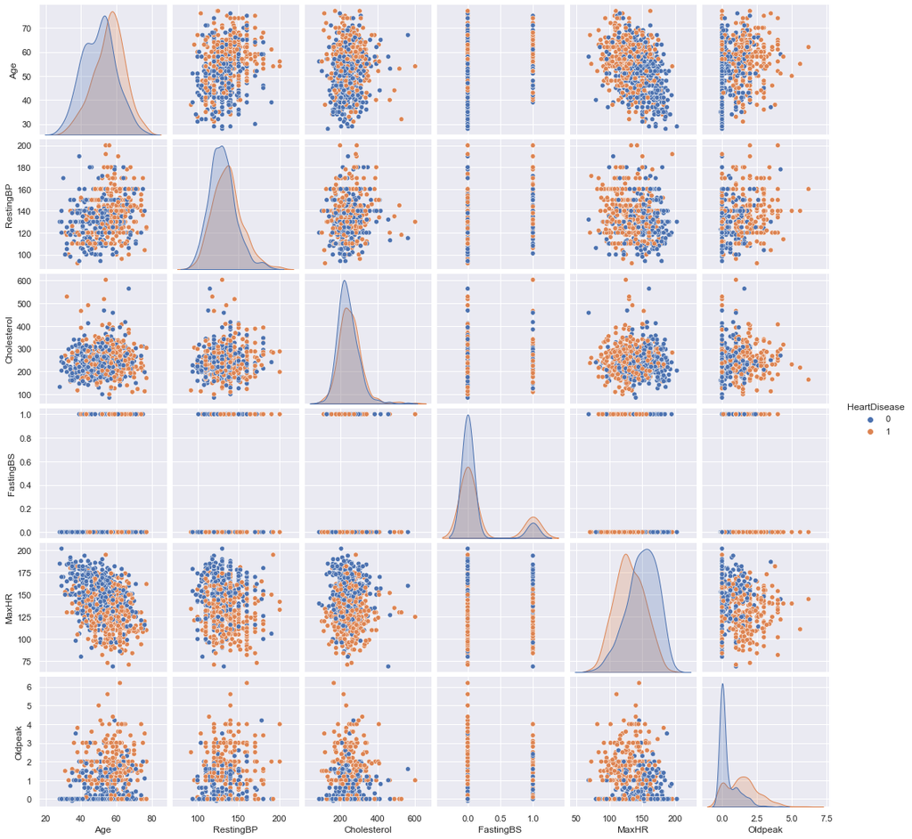

```python
sns.pairplot(data, hue="HeartDisease")
```

### 💡 Findings

We see some definite distinctions here with Oldpeak, MaxHR, Age and FastingBS  
Where they so grouping based on the outcome of the heart disease.

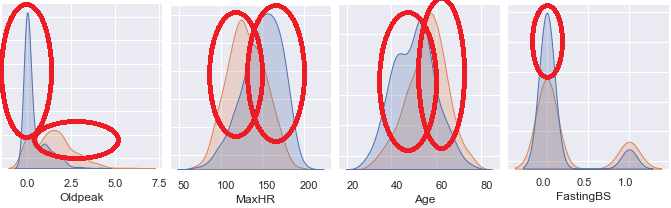

```python
Image(filename='Images/grouping2.png')
```

### 💡 CONCLUSION

We gained a lot from this data analysis.  
-We found out that men are more likely to get heart disease.  
-We found out that exercise is a good way to know if you could have heart disease.  
-We found out that heart disease doesn't cause Chest pain passively.  
-We found out that heart disease is more apparent in older people.  
-We found out that an Oldpeak of > 0 increases your chance of having heart disease.  
-We found out that a higher MaxHR lowers your chance of having heart disease.

### 👨‍💻 MODEL CREATION

### 💡 Info

```python
X = dataFrameOne.drop(['HeartDisease'],axis=1)
y = dataFrameOne['HeartDisease']

print(f'''
      The shape of X is {X.shape} and the type is {type(X)}
      The shape of y is {y.shape} and the type is {type(y)}
      ''')
```

```
      The shape of X is (746, 19) and the type is <class 'pandas.core.frame.DataFrame'>
      The shape of y is (746,) and the type is <class 'pandas.core.series.Series'>
```

### 💡 Findings

```python
X.head()
```

|  | Age | RestingBP | Cholesterol | FastingBS | MaxHR | Oldpeak | ChestPainType_ASY | ChestPainType_ATA | ChestPainType_NAP | ChestPainType_TA | RestingECG_LVH | RestingECG_Normal | RestingECG_ST | ExerciseAngina_N | ExerciseAngina_Y | ST_Slope_Down | ST_Slope_Flat | ST_Slope_Up | Sex_M |
| --- | --- | --- | --- | --- | --- | --- | --- | --- | --- | --- | --- | --- | --- | --- | --- | --- | --- | --- | --- |
| 0 | 40 | 140.0 | 289.0 | 0 | 172 | 0.0 | 0 | 1 | 0 | 0 | 0 | 1 | 0 | 1 | 0 | 0 | 0 | 1 | 1 |
| 1 | 49 | 160.0 | 180.0 | 0 | 156 | 1.0 | 0 | 0 | 1 | 0 | 0 | 1 | 0 | 1 | 0 | 0 | 1 | 0 | 0 |
| 2 | 37 | 130.0 | 283.0 | 0 | 98 | 0.0 | 0 | 1 | 0 | 0 | 0 | 0 | 1 | 1 | 0 | 0 | 0 | 1 | 1 |
| 3 | 48 | 138.0 | 214.0 | 0 | 108 | 1.5 | 1 | 0 | 0 | 0 | 0 | 1 | 0 | 0 | 1 | 0 | 1 | 0 | 0 |
| 4 | 54 | 150.0 | 195.0 | 0 | 122 | 0.0 | 0 | 0 | 1 | 0 | 0 | 1 | 0 | 1 | 0 | 0 | 0 | 1 | 1 |

```python
y.head()
```

```
0    0
1    1
2    0
3    1
4    0
Name: HeartDisease, dtype: int8
```

### 💡 Findings

Looks good.

Let's scale down the numerical data.  
This will help us to build a model that is more accurate and faster.  
It will take all the numbers and scale them down to a range of 0 to 1.

For this we will use sklearn's MinMaxScaler and we will only scale the relevant columns.

```python
scaler = MinMaxScaler()
X[num_cols] = scaler.fit_transform(X[num_cols])
print(f'''
      The columns affected will be {num_cols}''')
X.head()
```

```
      The columns affected will be ['Age', 'RestingBP', 'Cholesterol', 'MaxHR', 'Oldpeak']
```

|  | Age | RestingBP | Cholesterol | FastingBS | MaxHR | Oldpeak | ChestPainType_ASY | ChestPainType_ATA | ChestPainType_NAP | ChestPainType_TA | RestingECG_LVH | RestingECG_Normal | RestingECG_ST | ExerciseAngina_N | ExerciseAngina_Y | ST_Slope_Down | ST_Slope_Flat | ST_Slope_Up | Sex_M |
| --- | --- | --- | --- | --- | --- | --- | --- | --- | --- | --- | --- | --- | --- | --- | --- | --- | --- | --- | --- |
| 0 | 0.244898 | 0.444444 | 0.393822 | 0 | 0.774436 | 0.015871 | 0 | 1 | 0 | 0 | 0 | 1 | 0 | 1 | 0 | 0 | 0 | 1 | 1 |
| 1 | 0.428571 | 0.629630 | 0.183398 | 0 | 0.654135 | 0.174622 | 0 | 0 | 1 | 0 | 0 | 1 | 0 | 1 | 0 | 0 | 1 | 0 | 0 |
| 2 | 0.183673 | 0.351852 | 0.382239 | 0 | 0.218045 | 0.015871 | 0 | 1 | 0 | 0 | 0 | 0 | 1 | 1 | 0 | 0 | 0 | 1 | 1 |
| 3 | 0.408163 | 0.425926 | 0.249035 | 0 | 0.293233 | 0.253997 | 1 | 0 | 0 | 0 | 0 | 1 | 0 | 0 | 1 | 0 | 1 | 0 | 0 |
| 4 | 0.530612 | 0.537037 | 0.212355 | 0 | 0.398496 | 0.015871 | 0 | 0 | 1 | 0 | 0 | 1 | 0 | 1 | 0 | 0 | 0 | 1 | 1 |

### 💡 Findings

Looks like it all went well.

Let's visualise what happened. Let's look at age before and after being scaled.

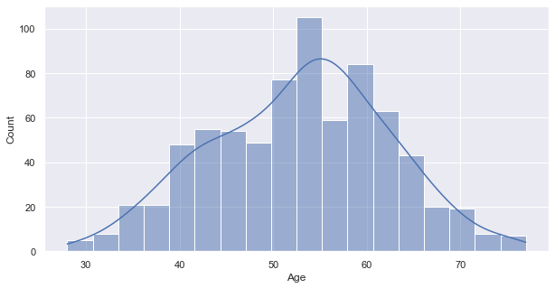

```python
'''
BEFORE BEING SCALED:
'''

plt.figure(figsize=(10,5))
sns.histplot(data['Age'],kde=True)
```

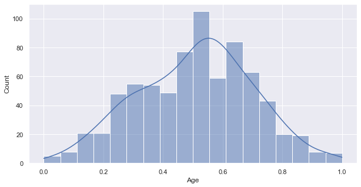

```python
'''
AFTER IT WAS SCALED:
'''
plt.figure(figsize=(10,5))
sns.histplot(X['Age'],kde=True)
```

### 💡 Findings

We see that the distribution of the data has not changed at all. <-- Important to note. Instead what has happened it that the scale of the X axis has been changed from being between 30 and 70 To being between 0 and 1.

The next step is to split the data into a training set and a test set. We will NOT train the data using any of the testing data.

We will use the sklearn library to import the train_test_split function. Which will automatically breakup our data. For now we will use 80% training set and 20% test set. And a random state of 42 to keep it consistent.

We are also not going to work with any scaled data. The reason is that we are going to use a pipeline to scale the data anyway. So this let's us analyse unscaled data but build the model using scaled data automatically.

```python
X = dataFrameOne.drop(['HeartDisease'],axis=1)
y = dataFrameOne['HeartDisease']

X_train, X_test, y_train, y_test = train_test_split(X, y, test_size = 0.2, random_state=42)
```

```python
X_train.describe()
```

|  | Age | RestingBP | Cholesterol | FastingBS | MaxHR | Oldpeak | ChestPainType_ASY | ChestPainType_ATA | ChestPainType_NAP | ChestPainType_TA | RestingECG_LVH | RestingECG_Normal | RestingECG_ST | ExerciseAngina_N | ExerciseAngina_Y | ST_Slope_Down | ST_Slope_Flat | ST_Slope_Up | Sex_M |
| --- | --- | --- | --- | --- | --- | --- | --- | --- | --- | --- | --- | --- | --- | --- | --- | --- | --- | --- | --- |
| count | 596.000000 | 596.000000 | 596.000000 | 596.000000 | 596.000000 | 596.000000 | 596.000000 | 596.000000 | 596.000000 | 596.000000 | 596.000000 | 596.000000 | 596.000000 | 596.000000 | 596.000000 | 596.000000 | 596.000000 | 596.000000 | 596.000000 |
| mean | 52.837248 | 132.741611 | 245.050336 | 0.157718 | 140.256711 | 0.905273 | 0.498322 | 0.226510 | 0.224832 | 0.050336 | 0.231544 | 0.607383 | 0.161074 | 0.622483 | 0.377517 | 0.052013 | 0.476510 | 0.471477 | 0.750000 |
| std | 9.425445 | 17.095688 | 58.728495 | 0.364783 | 24.552182 | 1.062500 | 0.500417 | 0.418924 | 0.417822 | 0.218820 | 0.422173 | 0.488743 | 0.367908 | 0.485173 | 0.485173 | 0.222241 | 0.499867 | 0.499605 | 0.433376 |
| min | 29.000000 | 92.000000 | 85.000000 | 0.000000 | 69.000000 | -0.099976 | 0.000000 | 0.000000 | 0.000000 | 0.000000 | 0.000000 | 0.000000 | 0.000000 | 0.000000 | 0.000000 | 0.000000 | 0.000000 | 0.000000 | 0.000000 |
| 25% | 46.000000 | 120.000000 | 208.750000 | 0.000000 | 122.750000 | 0.000000 | 0.000000 | 0.000000 | 0.000000 | 0.000000 | 0.000000 | 0.000000 | 0.000000 | 0.000000 | 0.000000 | 0.000000 | 0.000000 | 0.000000 | 0.750000 |
| 50% | 54.000000 | 130.000000 | 236.500000 | 0.000000 | 140.000000 | 0.500000 | 0.000000 | 0.000000 | 0.000000 | 0.000000 | 0.000000 | 1.000000 | 0.000000 | 1.000000 | 0.000000 | 0.000000 | 0.000000 | 0.000000 | 1.000000 |
| 75% | 59.000000 | 140.000000 | 275.000000 | 0.000000 | 160.000000 | 1.500000 | 1.000000 | 0.000000 | 0.000000 | 0.000000 | 0.000000 | 1.000000 | 0.000000 | 1.000000 | 1.000000 | 0.000000 | 1.000000 | 1.000000 | 1.000000 |
| max | 77.000000 | 200.000000 | 603.000000 | 1.000000 | 202.000000 | 5.601562 | 1.000000 | 1.000000 | 1.000000 | 1.000000 | 1.000000 | 1.000000 | 1.000000 | 1.000000 | 1.000000 | 1.000000 | 1.000000 | 1.000000 | 1.000000 |

## Random Forest Classification

### 💡 Findings

We see that 80% of the data has gone into the X_train and y_train variables. The remaining 20% will be in the X_test and y_test variables.

Let's first take a look at the random forest classification model.

First we import the nessicary classes. For this we will need the RandomForestClassifier method and the make_pipeline method. The pipeline will scale our data before training and testing the model.

```
[0.83333333 0.8487395  0.79831933 0.76470588 0.81512605]
The average score was 0.8120448179271709
              precision    recall  f1-score   support

           0       0.79      0.93      0.85        71
           1       0.92      0.77      0.84        79

    accuracy                           0.85       150
   macro avg       0.85      0.85      0.85       150
weighted avg       0.86      0.85      0.85       150
```

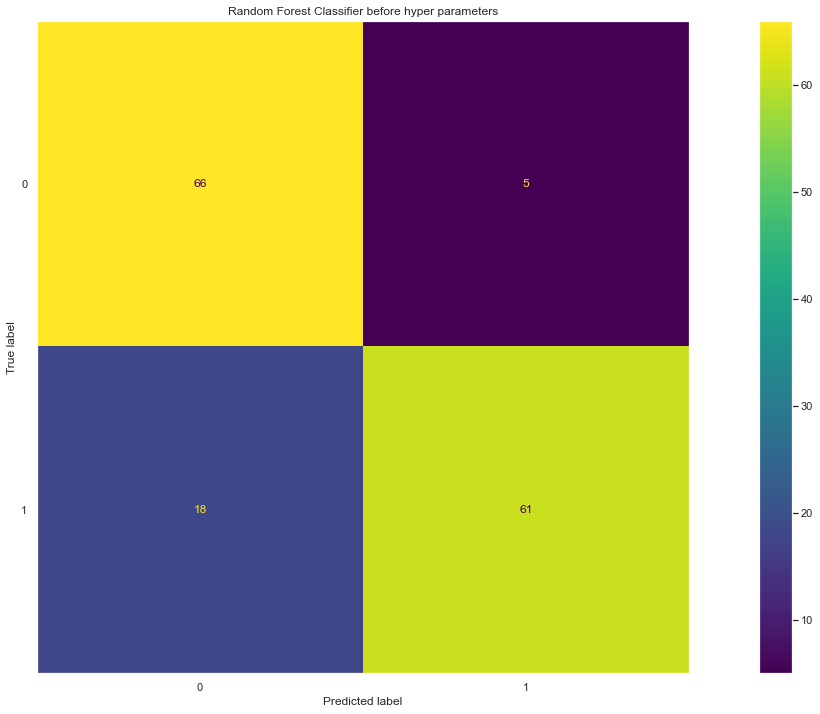

```python
ignoreWarnings()
rf_pipe = make_pipeline(scaler, RandomForestClassifier(n_estimators=4)) #We use 4 trees

rf_pipe.fit(X_train, y_train) #We fit the model

outputs = cross_val_score(rf_pipe, X_train, y_train, cv=5, scoring='accuracy') #We get outputs
averageScore_rf = outputs.mean() #We get the average score
y_pred = rf_pipe.predict(X_test) #We get the predictions
print(outputs)
print(f'The average score was {averageScore_rf}')

print(classification_report(y_test, y_pred))
plot_confusion_matrix(rf_pipe, X_test, y_test)
plt.grid(False)
plt.title('Random Forest Classifier before hyper parameters')
```

```python
#Number of trees
n_estimators = [int(x) for x in np.linspace(start = 10, stop = 80, num = 10)]

#Number of features to consider at every split
max_features = ['auto', 'sqrt']

#Maximum number of levels in tree
max_depth = [2,4]

#Minimum number of samples required to split a node
min_sample_split = [2, 5]

#Minimum number of samples required at each leaf node
min_sample_leaf = [1, 2]

#Method of selecting samples for training each tree
bootstrap = [True, False]

param_grid = [{'n_estimators': n_estimators,
               'max_features': max_features,
               'max_depth': max_depth,
               'min_samples_split': min_sample_split,
               'min_samples_leaf': min_sample_leaf,
               'bootstrap': bootstrap}]

print(param_grid)
```

```
[{'n_estimators': [10, 17, 25, 33, 41, 48, 56, 64, 72, 80], 'max_features': ['auto', 'sqrt'], 'max_depth': [2, 4], 'min_samples_split': [2, 5], 'min_samples_leaf': [1, 2], 'bootstrap': [True, False]}]
```

```python
rf_Grid = GridSearchCV(estimator = RandomForestClassifier(), param_grid = param_grid, cv = 5, n_jobs = 4, verbose = 2)#
rf_Grid.fit(X_train, y_train)
bestParams = rf_Grid.best_params_
print(f'''
      n_estimators: {bestParams["n_estimators"]}
      min_samples_split: {bestParams["min_samples_split"]}
      min_samples_leaf: {bestParams["min_samples_leaf"]}
      max_features: {bestParams["max_features"]}
      max_depth: {bestParams["max_depth"]}
      bootstrap: {bestParams["bootstrap"]}''')
```

```
Fitting 5 folds for each of 320 candidates, totalling 1600 fits

      n_estimators: 56
      min_samples_split: 5
      min_samples_leaf: 2
      max_features: sqrt
      max_depth: 4
      bootstrap: False
```

```python
rf_pipe = make_pipeline(scaler, RandomForestClassifier(n_estimators=bestParams['n_estimators'], max_features=bestParams['max_features'], max_depth=bestParams['max_depth'], min_samples_split=bestParams['min_samples_split'], min_samples_leaf=bestParams['min_samples_leaf'], bootstrap=bestParams['bootstrap']))
```

```python
rf_pipe.fit(X_train, y_train)
averageScore_rf = cross_val_score(rf_pipe, X_train, y_train, cv=5, scoring='accuracy')
print(averageScore_rf)
print(averageScore_rf.mean())

y_pred = rf_pipe.predict(X_test)
finalAccuracy_rf = accuracy_score(y_test, y_pred)
print(finalAccuracy_rf)
```

```
[0.81666667 0.85714286 0.87394958 0.80672269 0.86554622]
0.8440056022408964
0.9
```

```
              precision    recall  f1-score   support

           0       0.89      0.90      0.90        71
           1       0.91      0.90      0.90        79

    accuracy                           0.90       150
   macro avg       0.90      0.90      0.90       150
weighted avg       0.90      0.90      0.90       150
```

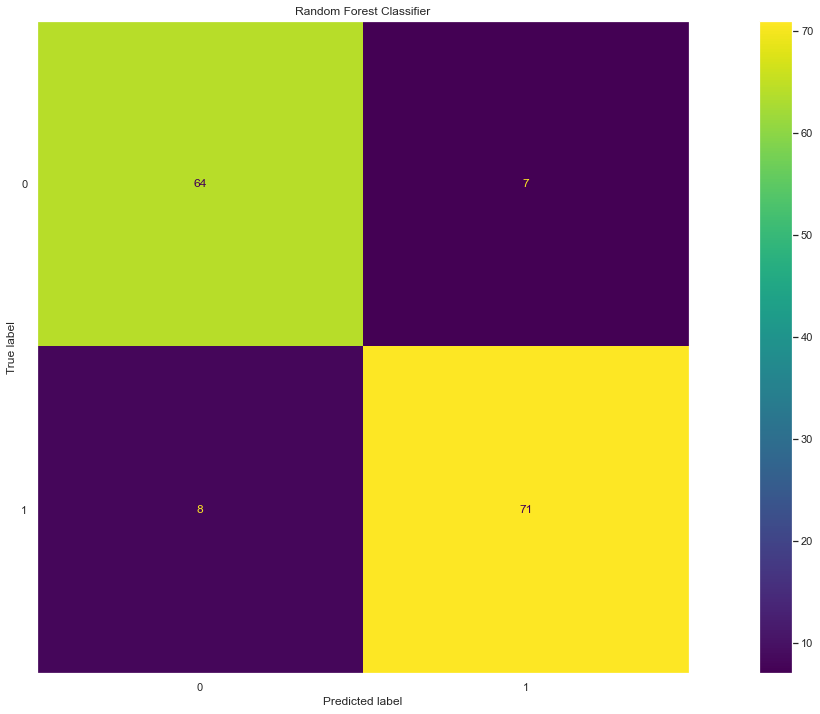

```python
print(classification_report(y_test, y_pred))
plot_confusion_matrix(rf_pipe, X_test, y_test)
plt.grid(False)
plt.title('Random Forest Classifier')
```